# Data Science Co-authorship Analysis

Zachary Beisler

12/11/2019

# Finding Erdos-like Researchers Data Science Co-authorhip Graphs

```r
DBLP1 <- read.table("DBLP1.txt", sep = '\t',header = FALSE)
DBLP2 <- read.table("DBLP2.txt", sep = '\t',header = FALSE)

glimpse(DBLP1)
```

```
## Observations: 136,062
## Variables: 2
## $ V1 <int> 1225, 3245, 10889, 3, 13116, 26, 108, 5016, 8595, 12776, 1280…
## $ V2 <int> 1, 1, 1, 2, 2, 3, 3, 3, 3, 3, 3, 3, 3, 3, 3, 3, 3, 3, 3, 3, 3…
```

```r
glimpse(DBLP2)
```

```
## Observations: 64,152
## Variables: 2
## $ V1 <int> 198, 330, 3061, 4377, 6357, 6358, 10120, 3, 278, 116, 134, 13…
## $ V2 <int> 1, 1, 1, 1, 1, 1, 1, 2, 2, 3, 3, 3, 3, 3, 3, 3, 3, 3, 3, 3, 3…
```

Here we load two graph datasets, taken from [here](https://www.cs.utexas.edu/~xmao/coauthorship). We will be looking for what I will call “Erdos-like” nodes in the two datasets. Paul Erdos was a famous mathematician who, among his mathematical works, is well-known for having authored/co-authored many important papers with many other proilifc mathematicians. Becuase of this, if you construct a graph where the nodes are authors of math research papers and the edges indicate that two authors have co-authored a paper together, most other authors have a shortest path length to Erdos of less than 6. In this project, I will attempt to find authors of data science papers that share this Erdos-like characteristic.

## R Markdown

```r
compute_degrees <- function(graph_df){
  Reverse_Edges <- graph_df %>% select(V1 = V2, V2 = V1)

  Degrees <- rbind(Reverse_Edges, graph_df) %>%
    group_by(V1) %>%
    summarise(Degree = n()) %>%
    arrange(desc(Degree))

  return(Degrees)
}

DBLP1_degrees <- compute_degrees(DBLP1)
DBLP2_degrees <- compute_degrees(DBLP2)
DBLP1_degrees
```

```
## # A tibble: 30,566 x 2
##       V1 Degree
##    <int>  <int>
##  1   524    272
##  2   624    229
##  3  8615    203
##  4 10361    200
##  5 16842    195
##  6   464    192
##  7  6575    170
##  8  8172    169
##  9 16949    167
## 10   334    166
## # … with 30,556 more rows
```

Here is the function for computing the degree of each node in the dataset. Note that the datasets are anonymized, so that instead of the author’s name each node is a unique identifier. The dataset is in the form of an edge list, so that each row is two columns: the starting node and the ending node. Because co-authorship is not directed, we have to reverse the dataset and then do a union (rbind()) to relfect each edge both ways. After this we can group on the originiating node and simply count the connections that it makes.

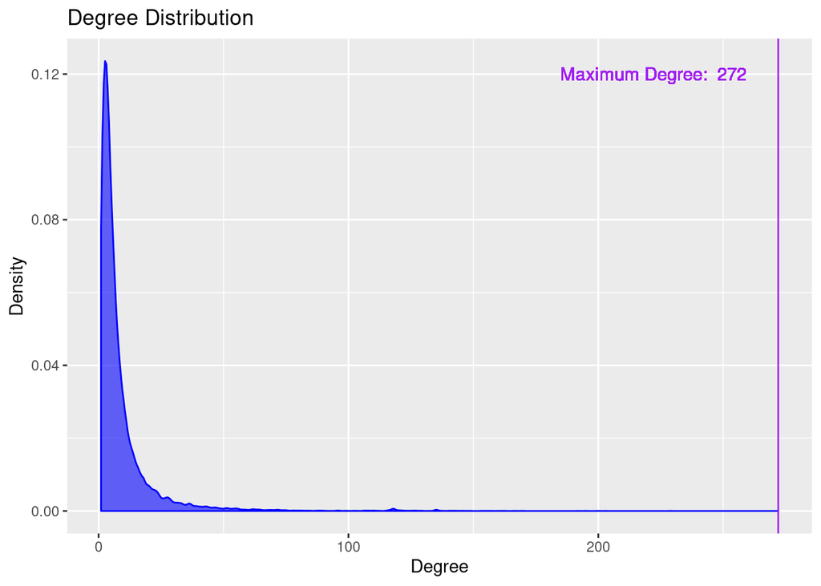

```r
degree_distribution <- function(Degrees, show_max=TRUE){
  plot <- ggplot(Degrees, aes(x = Degree)) + geom_density(color="blue", fill="blue", alpha=0.6) + ggtitle("Degree Distribution") + ylab("Density")

  if(show_max){
    highest_degree <- max(Degrees$Degree)
    plot <- plot + geom_vline(aes(xintercept=highest_degree), color="purple") + geom_text(aes(x=highest_degree - 50, y=0.12, label=paste("Maximum Degree: ", as.character(highest_degree))), color="purple")
  }

  return(plot)
}

degree_distribution(DBLP1_degrees)
```

This grap above depicts the degree distribution for the DPLB1 graph dataset. Below is a graph that compares the distributions between the two datasets:

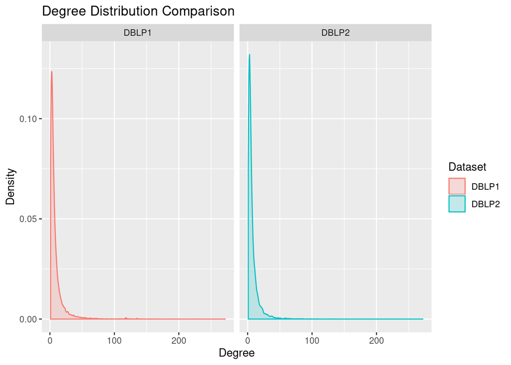

```r
Both_degrees <- DBLP1_degrees %>%
  mutate(Dataset = "DBLP1") %>%
  rbind(DBLP2_degrees %>% mutate(Dataset = "DBLP2"))

Both_degrees %>% ggplot(aes(x = Degree, color=Dataset, fill=Dataset)) + facet_grid(cols=vars(Dataset)) + geom_density(alpha=0.2) + ggtitle("Degree Distribution Comparison") + ylab("Density")
```

The comparison shows that the degree distribution for each of the two datasets is essentially the same, which supports the idea that co-authorship graphs are the same across fields. This lead mes to believe that there will be instances of Erdos-like nodes in each of the datasets.

The id of the node with maximum degree in the DBLP1 dataset is node 524. I will construct a histogram of shortest path lengths to this node to check if it exhibits Erdos-like behaviour; that is if shortest path lengths are generally bounded above by a small constant.

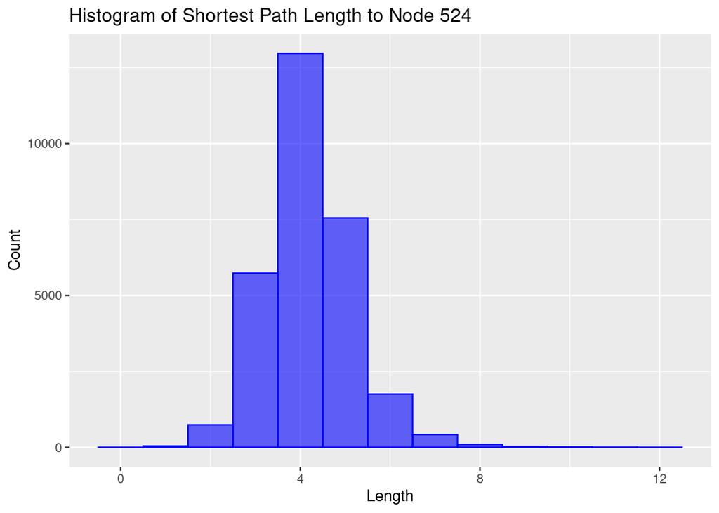

```r
DBLP1_graph <- graph_from_data_frame(DBLP1, directed=FALSE)
DBLP2_graph <- graph_from_data_frame(DBLP2, directed=FALSE)

ComputeShortestPaths <- function(graph, node){
  ShortestPaths <- as.data.frame(t(shortest.paths(graph, v=node, mode = "in")))

  col_name = colnames(ShortestPaths)[1]

  ShortestPaths <- ShortestPaths %>%
    select(Length = col_name) %>%
    filter(is.finite(Length))
  return(ShortestPaths)
}

Paths_524 <- ComputeShortestPaths(DBLP1_graph, 524)

Paths_524 %>% ggplot(aes(x=Length)) + geom_histogram(color="blue", fill="blue", alpha=0.6, binwidth=1) + ggtitle("Histogram of Shortest Path Length to Node 524") + ylab("Count")
```

From the graph above it seems that node 524 is indeed Erdos-like, and its shortest paths are generally bounded above by 8. To illustrate what an Erdos-like node looks like in comparison to a random non Erdos-like node, I will plot the shortest path distributions of node 524 and node 957 together below:

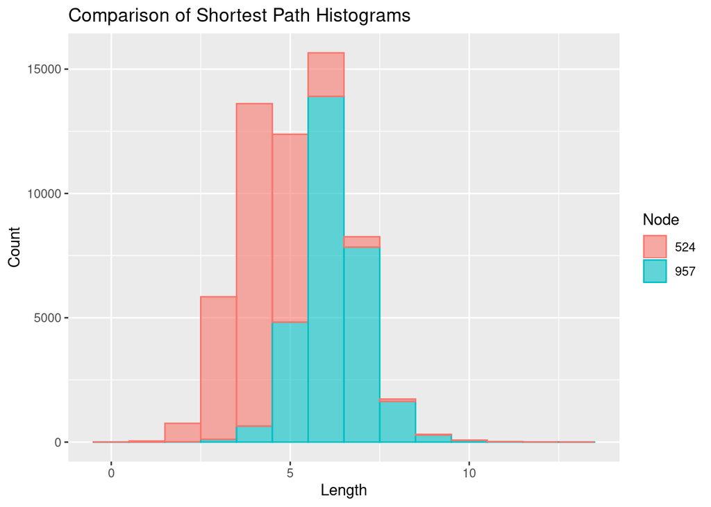

```r
Paths_957 <- ComputeShortestPaths(DBLP1_graph, 957)

Paths_524 %>%
  mutate(Node = "524") %>%
  rbind(Paths_957 %>% mutate(Node = "957")) %>%
  ggplot(aes(x=Length, fill=Node, color=Node)) + geom_histogram(alpha=0.6, binwidth=1) + ggtitle("Comparison of Shortest Path Histograms") + ylab("Count")
```

Because this is a highly connected graph, node 957’s path length distribution is still centered around a small number. However, node 524’s distribution has a noticably lower centering point. We can quantify this difference by looking at the mean path length for each of the nodes.

```r
Paths_524 %>%
  summarise(AverageLength = mean(Length)) %>%
  mutate(Node = "524") %>%
  rbind(Paths_957 %>%
          summarise(AverageLength = mean(Length)) %>%
          mutate(Node = "957")
        ) %>%
  arrange(AverageLength)
```

```
##   AverageLength Node
## 1      4.190173  524
## 2      6.198964  957
```

Node 524 has a much lower average path length than node 957. In conclusion, it seems that node 524 from the DBLP1 dataset is an Erdo-like node, and it seems that co-authorship graphs share the characterisitic of having well-connected central nodes in them.